# Prediction Assignment Writeup (Machine Learning)

Alexey Pogorelov

25/11/2018

## Data analysis, pre-processing

1. Download the data with read.csv function.

```r
pml_training<-read.csv("~/Downloads/pml-training.csv")
```

2. The data contains 19622 obs and 160 vars.

```r
dim(pml_training)
```

```
## [1] 19622   160
```

3. Having looked through the data, i’ve noticed that it contains lots of NA observations and empty cells.
4. I downloaded pml_training set one more time, but this time treating all empty cells as NAs

```r
pml_training<-read.csv("/Users/alexeypogorelov/Downloads/pml-training.csv",na.strings = c('',' ','NA'))
```

5. I’ve checked and identified those cells, with the largest number of NAs.

```r
pml_training1<-pml_training %>%
  summarise_all(funs(sum(is.na(.))/19622))
```

6. I removed those vars, in which share of NAs exceed 90%.

```r
pml_training<-pml_training[,-which(pml_training1>0.9)]
```

7. The new data.frame contains only 60 variables

```r
dim(pml_training)
```

```
## [1] 19622    60
```

8. In order to finish clean-up procedure i also removed those vars that give no additional information for our modeling purpose. These are first 7 vars that represent the name of the person, time, new_window, observation number and etc.

```r
pml_training<-pml_training[,-c(1:7)]
```

9. The new data.frame contains only 53 variables

```r
dim(pml_training)
```

```
## [1] 19622    53
```

## Fitting the model

Next step, i partition the data into train and test subsets.

```r
set1<-createDataPartition(y=pml_training$classe,p=0.7,list = FALSE)

trainset1<-pml_training[set1,]
testset1<-pml_training[-set1,]
```

I set resampling parameters for repeated cross-validation.

```r
fitControl <- trainControl(method = "repeatedcv", number = 10, repeats = 5)
```

Biulding model1. Since model building takes a lot of time, i will load pre-run models from the Global environment.

```r
load("~/Documents/data1.RData")
```

Code for building the model 1. Rpart model.

```r
model1<-train(classe~.,method="rpart",data=trainset1,trControl=fitControl)
print(model1$finalModel)
```

### Model1 output. Rpart model

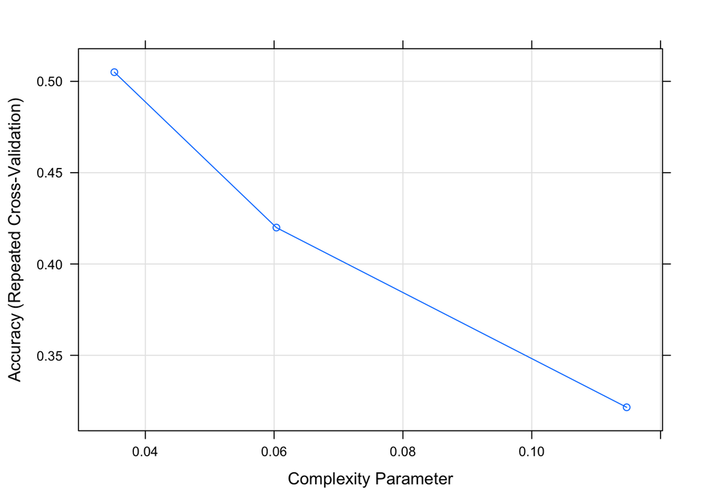

```r
plot(model1)
```

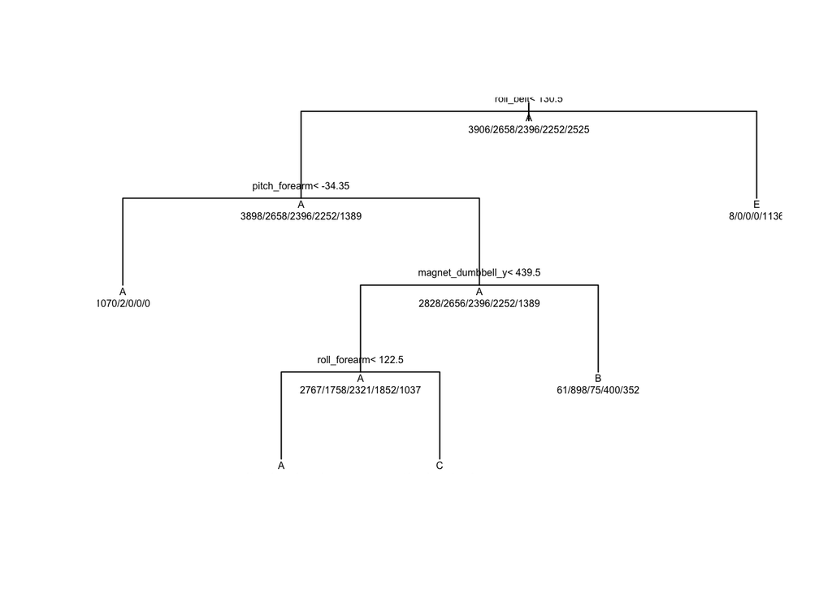

```r
plot(model1$finalModel,uniform = TRUE,
     main="")
text(model1$finalModel,use.n = TRUE,all = TRUE,cex=0.5)
```

```r
table(predict(model1,testset1),testset1$classe)
```

```
##
##        A    B    C    D    E
##   A 1526  463  499  436  151
##   B   20  388   33  168  134
##   C  122  288  494  360  302
##   D    0    0    0    0    0
##   E    6    0    0    0  495
```

Code for building the model 2. GBM model.

```r
gbmGrid <-  expand.grid(interaction.depth = c(1,2,3),
                        n.trees = (1:10)*20,
                        shrinkage = 0.1,
                        n.minobsinnode = 20)
model2<-train(classe~.,method="gbm",data=trainset1,verbose=FALSE,tuneGrid = gbmGrid)

print(model2$finalModel)
```

### Model2 output. GBM model.

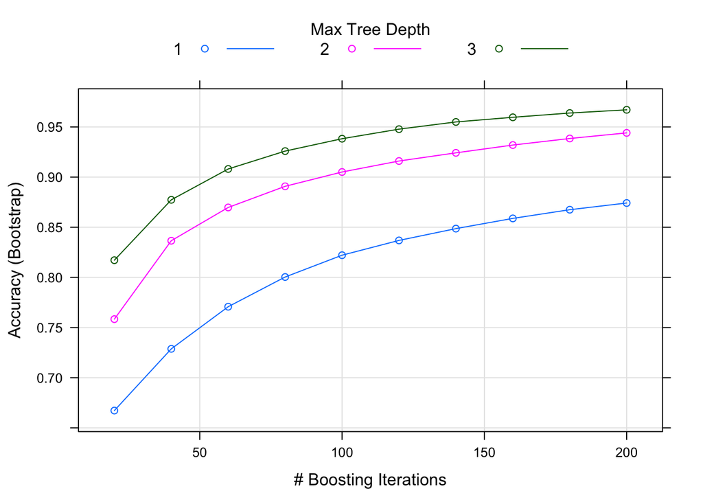

```r
plot(model2)
```

```r
table(predict(model2,testset1),testset1$classe)
```

```
##
##        A    B    C    D    E
##   A 1654   21    0    1    0
##   B   13 1097   22    1    5
##   C    7   20  997   32    6
##   D    0    1    7  920   15
##   E    0    0    0   10 1056
```

Code for building the model 3. Rpart2 model.

```r
model3<-train(classe~.,method="rpart2",data=trainset1,trControl=fitControl,tuneLength=10)

print(model3$finalModel)
```

### Model3 output. Rpart2 model.

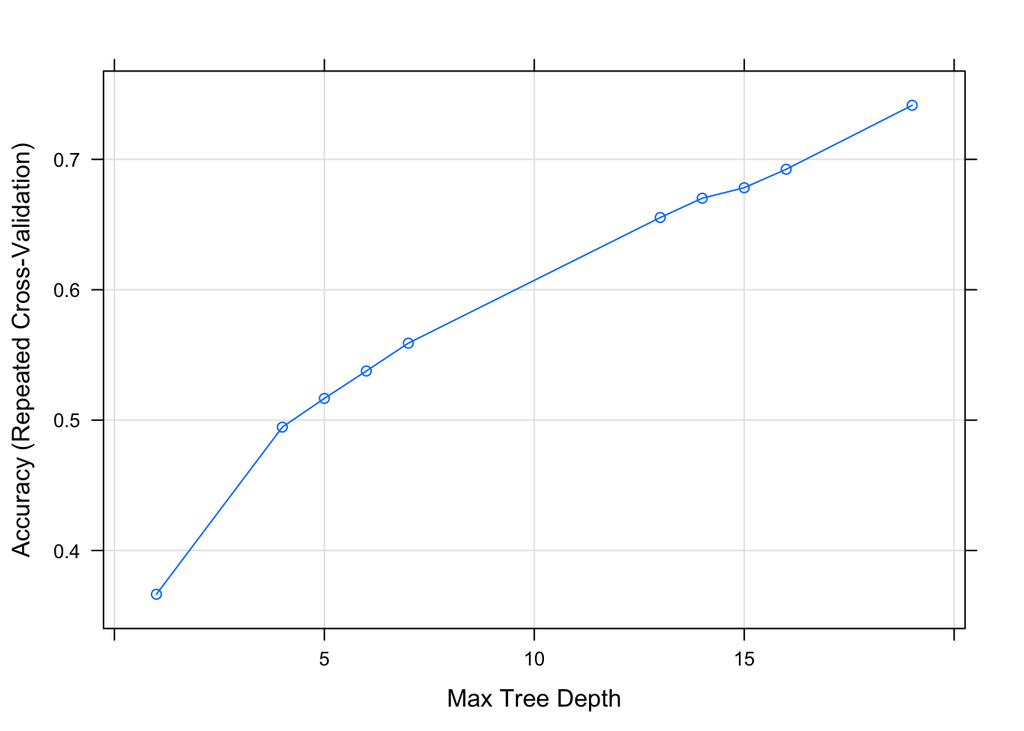

```r
plot(model3)
```

```r
table(predict(model3,testset1),testset1$classe)
```

```
##
##        A    B    C    D    E
##   A 1553  223   20   94   28
##   B   31  567   48   24   71
##   C   44  177  833  151  152
##   D   16   91   65  602   61
##   E   30   81   60   93  770
```

Code for building the model 4. ctree2 model.

```r
model4<-train(classe~.,method="ctree2",data=trainset1,trControl=fitControl,tuneLength=10)

print(model4$finalModel)
```

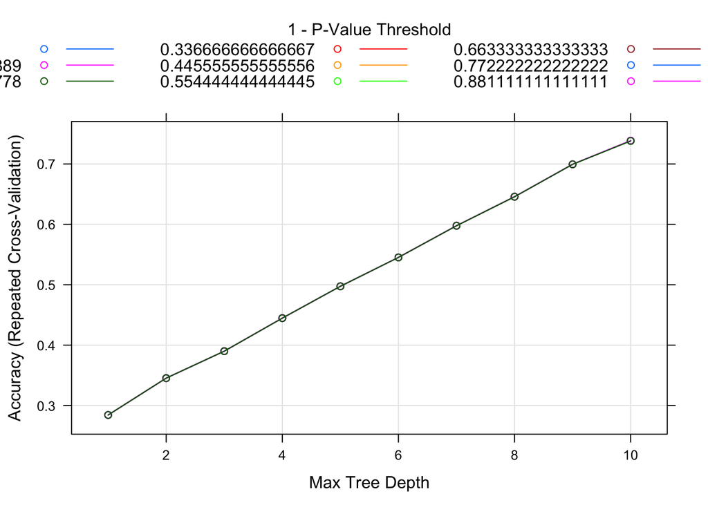

```r
plot(model4)
```

```r
table(predict(model4,testset1),testset1$classe)
```

```
##
##        A    B    C    D    E
##   A 1450  155   58   55   37
##   B   58  684   78   80  151
##   C   26   85  820  134  108
##   D  104  109   34  671   75
##   E   36  106   36   24  711
```

## Confusion matrix output for all four models.

```r
confusionMatrix(testset1$classe,predict(model1,testset1))$overall['Accuracy']
```

```
## Accuracy
## 0.493288
```

```r
confusionMatrix(testset1$classe,predict(model2,testset1))$overall['Accuracy']
```

```
##  Accuracy
## 0.9726423
```

```r
confusionMatrix(testset1$classe,predict(model3,testset1))$overall['Accuracy']
```

```
##  Accuracy
## 0.7349193
```

```r
confusionMatrix(testset1$classe,predict(model4,testset1))$overall['Accuracy']
```

```
##  Accuracy
## 0.7367884
```

```r
confusionMatrix(testset1$classe,predict(model1,testset1))$table
```

```
##           Reference
## Prediction    A    B    C    D    E
##          A 1526   20  122    0    6
##          B  463  388  288    0    0
##          C  499   33  494    0    0
##          D  436  168  360    0    0
##          E  151  134  302    0  495
```

```r
confusionMatrix(testset1$classe,predict(model2,testset1))$table
```

```
##           Reference
## Prediction    A    B    C    D    E
##          A 1654   13    7    0    0
##          B   21 1097   20    1    0
##          C    0   22  997    7    0
##          D    1    1   32  920   10
##          E    0    5    6   15 1056
```

```r
confusionMatrix(testset1$classe,predict(model3,testset1))$table
```

```
##           Reference
## Prediction    A    B    C    D    E
##          A 1553   31   44   16   30
##          B  223  567  177   91   81
##          C   20   48  833   65   60
##          D   94   24  151  602   93
##          E   28   71  152   61  770
```

```r
confusionMatrix(testset1$classe,predict(model4,testset1))$table
```

```
##           Reference
## Prediction    A    B    C    D    E
##          A 1450   58   26  104   36
##          B  155  684   85  109  106
##          C   58   78  820   34   36
##          D   55   80  134  671   24
##          E   37  151  108   75  711
```

## Model 2 is the best model